# SARIMA Intervensi

### Model 6

$ARIMA(0,1,1)×ARIMA(2,1,2)_{12}$

```r
model6 <- Arima(data_sblm_intervensi,order=c(0,1,1),seasonal=c(2,1,2))
     summary(model6)
```

```
## Series: data_sblm_intervensi
## ARIMA(0,1,1)(2,1,2)[12]
##
## Coefficients:
##           ma1     sar1     sar2     sma1     sma2
##       -0.3666  -0.6955  -0.0888  -0.0432  -0.6736
## s.e.   0.1125   0.2656   0.1929   0.2911   0.3430
##
## sigma^2 = 0.006689:  log likelihood = 124.64
## AIC=-237.28   AICc=-236.54   BIC=-220.56
##
## Training set error measures:
##                         ME       RMSE        MAE          MPE      MAPE
## Training set -0.0001712747 0.07605154 0.05292063 -0.003050102 0.4160147
##                  MASE       ACF1
## Training set 0.432471 0.06118428
```

```r
     lmtest::coeftest(model6) # parameter tidak signifikan
```

```
##
## z test of coefficients:
##
##       Estimate Std. Error z value Pr(>|z|)
## ma1  -0.366614   0.112476 -3.2595 0.001116 **
## sar1 -0.695454   0.265650 -2.6179 0.008846 **
## sar2 -0.088775   0.192895 -0.4602 0.645354
## sma1 -0.043203   0.291118 -0.1484 0.882023
## sma2 -0.673567   0.343001 -1.9637 0.049560 *
## ---
## Signif. codes:  0 '***' 0.001 '**' 0.01 '*' 0.05 '.' 0.1 ' ' 1
```

### Model 7

$ARIMA(2,1,0)×ARIMA(2,1,2)_{12}$

```r
model7 <- Arima(data_sblm_intervensi,order=c(2,1,0),seasonal=c(2,1,2))
     summary(model7)
```

```
## Series: data_sblm_intervensi
## ARIMA(2,1,0)(2,1,2)[12]
##
## Coefficients:
##           ar1      ar2     sar1     sar2     sma1     sma2
##       -0.3004  -0.1773  -0.6818  -0.0902  -0.0703  -0.6529
## s.e.   0.0952   0.0934   0.2940   0.1878   0.3117   0.3542
##
## sigma^2 = 0.006732:  log likelihood = 124.86
## AIC=-235.73   AICc=-234.73   BIC=-216.21
##
## Training set error measures:
##                         ME       RMSE        MAE          MPE      MAPE
## Training set -8.156081e-05 0.07596368 0.05334163 -0.002262712 0.4193175
##                   MASE       ACF1
## Training set 0.4359115 0.01403133
```

```r
     lmtest::coeftest(model7) # parameter tidak signifikan
```

```
##
## z test of coefficients:
##
##       Estimate Std. Error z value Pr(>|z|)
## ar1  -0.300378   0.095164 -3.1564 0.001597 **
## ar2  -0.177271   0.093351 -1.8990 0.057567 .
## sar1 -0.681795   0.294043 -2.3187 0.020412 *
## sar2 -0.090246   0.187842 -0.4804 0.630917
## sma1 -0.070305   0.311659 -0.2256 0.821525
## sma2 -0.652873   0.354196 -1.8433 0.065292 .
## ---
## Signif. codes:  0 '***' 0.001 '**' 0.01 '*' 0.05 '.' 0.1 ' ' 1
```

### Model 8

$ARIMA(0,1,2)×ARIMA(2,1,0)_{12}$

```r
model8 <- Arima(data_sblm_intervensi,order=c(0,1,2),seasonal=c(2,1,0))
     summary(model8)
```

```
## Series: data_sblm_intervensi
## ARIMA(0,1,2)(2,1,0)[12]
##
## Coefficients:
##           ma1      ma2     sar1     sar2
##       -0.4222  -0.3155  -0.5367  -0.4517
## s.e.   0.0927   0.1108   0.0857   0.0841
##
## sigma^2 = 0.007245:  log likelihood = 123.54
## AIC=-237.08   AICc=-236.55   BIC=-223.14
##
## Training set error measures:
##                         ME       RMSE        MAE          MPE      MAPE
## Training set -0.0003067198 0.07948988 0.05633389 -0.004299235 0.4424696
##                   MASE       ACF1
## Training set 0.4603645 0.04282319
```

```r
     lmtest::coeftest(model8) # parameter signifikan
```

```
##
## z test of coefficients:
##
##       Estimate Std. Error z value  Pr(>|z|)
## ma1  -0.422230   0.092655 -4.5570 5.188e-06 ***
## ma2  -0.315514   0.110771 -2.8484  0.004395 **
## sar1 -0.536681   0.085705 -6.2620 3.801e-10 ***
## sar2 -0.451684   0.084132 -5.3687 7.928e-08 ***
## ---
## Signif. codes:  0 '***' 0.001 '**' 0.01 '*' 0.05 '.' 0.1 ' ' 1
```

### Model 9

$ARIMA(1,1,2)×ARIMA(2,1,0)_{12}$

```r
model9 <- Arima(data_sblm_intervensi,order=c(1,1,2),seasonal=c(2,1,0))
     summary(model9)
```

```
## Series: data_sblm_intervensi
## ARIMA(1,1,2)(2,1,0)[12]
##
## Coefficients:
##          ar1      ma1     ma2    sar1     sar2
##       0.6654  -1.0984  0.1160  -0.525  -0.4579
## s.e.  0.2194   0.2924  0.2072   0.088   0.0867
##
## sigma^2 = 0.006834:  log likelihood = 126.51
## AIC=-241.02   AICc=-240.27   BIC=-224.29
##
## Training set error measures:
##                       ME       RMSE        MAE        MPE      MAPE      MASE
## Training set 0.003889774 0.07686863 0.05465067 0.02829977 0.4291982 0.4466091
##                     ACF1
## Training set 0.001274688
```

```r
     lmtest::coeftest(model9) # parameter tidak signifikan
```

```
##
## z test of coefficients:
##
##       Estimate Std. Error z value  Pr(>|z|)
## ar1   0.665376   0.219418  3.0325 0.0024257 **
## ma1  -1.098417   0.292432 -3.7562 0.0001725 ***
## ma2   0.116002   0.207241  0.5597 0.5756562
## sar1 -0.524964   0.088041 -5.9627 2.481e-09 ***
## sar2 -0.457919   0.086668 -5.2836 1.267e-07 ***
## ---
## Signif. codes:  0 '***' 0.001 '**' 0.01 '*' 0.05 '.' 0.1 ' ' 1
```

### Perbandingan Semua Model yang parameternya signifikan berdasarkan AIC

```r
aic_model_ov <- data.frame( "Nama Model" =c("ARIMA(2,1,0)×ARIMA(2,1,0)_{12}","ARIMA(0,1,1)×ARIMA(2,1,0)_{12}","ARIMA(0,1,2)×ARIMA(2,1,0)_{12}"),"AIC" = c(model2$aic,model3$aic,model8$aic))
aic_model_ov
```

```
##                       Nama.Model       AIC
## 1 ARIMA(2,1,0)×ARIMA(2,1,0)_{12} -232.0123
## 2 ARIMA(0,1,1)×ARIMA(2,1,0)_{12} -233.6334
## 3 ARIMA(0,1,2)×ARIMA(2,1,0)_{12} -237.0779
```

```r
dplyr::arrange(.data=aic_model_ov, AIC) #mengurutkan
```

```
##                       Nama.Model       AIC
## 1 ARIMA(0,1,2)×ARIMA(2,1,0)_{12} -237.0779
## 2 ARIMA(0,1,1)×ARIMA(2,1,0)_{12} -233.6334
## 3 ARIMA(2,1,0)×ARIMA(2,1,0)_{12} -232.0123
```

Model tentatif dipilih berdasarkan nilai AIC minimum dengan pertimbangan bahwa seluruh parameter signifikan. Oleh karena itu, model 8 yaitu $ARIMA(0,1,2)×ARIMA(2,1,0)_{12}$ yang menghasilkan seluruh parameter signifikan serta nilai AIC yang cukup minimum akan dianalisis lebih lanjut sebagai model tentatif serta akan digunakan untuk melakukan peramalan.

# Overfitting

$ARIMA(0,1,3)×ARIMA(2,1,0)_{12}$

```r
overf <- Arima(data_sblm_intervensi,order=c(0,1,3),seasonal=c(2,1,0))
     summary(overf)
```

```
## Series: data_sblm_intervensi
## ARIMA(0,1,3)(2,1,0)[12]
##
## Coefficients:
##           ma1      ma2      ma3     sar1     sar2
##       -0.4233  -0.2486  -0.1392  -0.5211  -0.4736
## s.e.   0.0934   0.1127   0.0872   0.0856   0.0832
##
## sigma^2 = 0.007111:  log likelihood = 124.76
## AIC=-237.52   AICc=-236.78   BIC=-220.79
##
## Training set error measures:
##                         ME       RMSE        MAE          MPE      MAPE
## Training set -0.0001047442 0.07841575 0.05563654 -0.002493643 0.4371951
##                   MASE      ACF1
## Training set 0.4546656 0.0229804
```

```r
     lmtest::coeftest(overf) # parameter tidak signifikan
```

```
##
## z test of coefficients:
##
##       Estimate Std. Error z value  Pr(>|z|)
## ma1  -0.423311   0.093362 -4.5341 5.786e-06 ***
## ma2  -0.248598   0.112655 -2.2067   0.02733 *
## ma3  -0.139187   0.087228 -1.5957   0.11056
## sar1 -0.521052   0.085638 -6.0843 1.170e-09 ***
## sar2 -0.473633   0.083206 -5.6923 1.253e-08 ***
## ---
## Signif. codes:  0 '***' 0.001 '**' 0.01 '*' 0.05 '.' 0.1 ' ' 1
```

Karena parameter yg overfiting ada yg tidak signifikan maka $ARIMA(0,1,2)×ARIMA(2,1,0)_{12}$ tetap menjadi yang terbaik.

# Diagnostik Model

Analisis Sisaan model $ARIMA(0,1,2)×ARIMA(2,1,0)_{12}$. Model terbaik hasil identifikasi kemudian dicek asumsi sisaannya. Sisaan model SARIMA harus memenuhi asumsi normalitas, kebebasan sisaan, dan kehomogenan ragam. Diagnostik model dilakukan secara eksplorasi dan uji formal.

## Eksplorasi

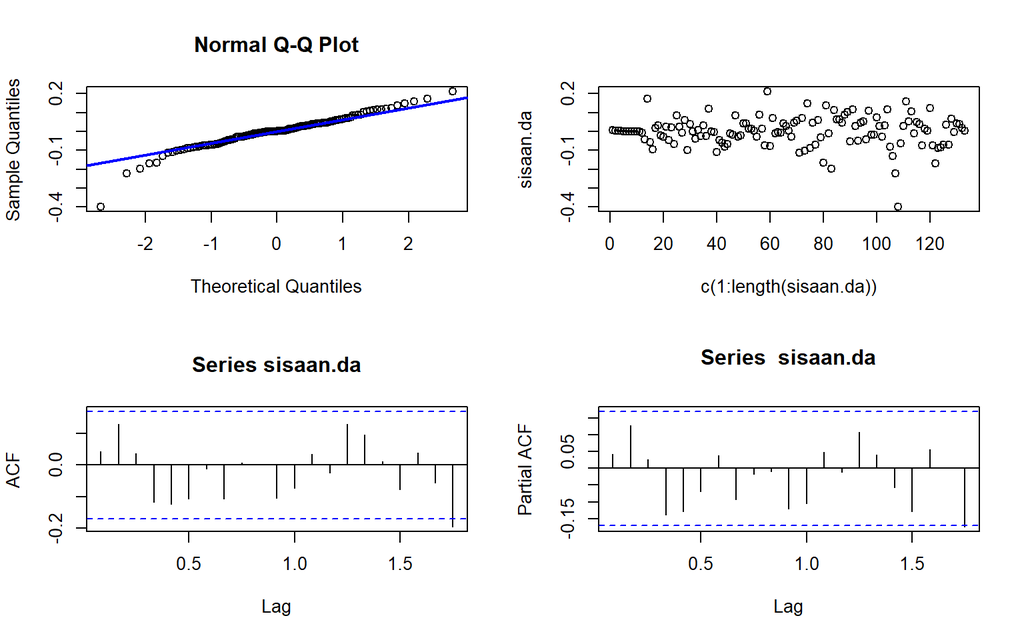

```r
sisaan.da <- model8$residuals
par(mfrow=c(2,2))
qqnorm(sisaan.da)
qqline(sisaan.da, col = "blue", lwd = 2)
plot(c(1:length(sisaan.da)),sisaan.da)
acf(sisaan.da)
pacf(sisaan.da)
```

```r
par(mfrow = c(1,1))
```

Berdasarkan plot kuantil-kuantil normal, secara eksplorasi ditunjukkan sisaan tidak menyebar normal ditandai dengan adanya titik-titik yang cenderung tidak mengikuti garis $45^{\circ}$. Kemudian dapat dilihat juga lebar pita sisaan yang cenderung sama menandakan bahwa sisaan memiliki ragam yang homogen. Plot ACF dan PACF sisaan model menunjukkan saling bebas. Kondisi ini akan diuji lebih lanjut dengan uji formal.

## Uji Formal

### 1) Sisaan Menyebar Normal

```r
ks.test(sisaan.da,"pnorm")
```

```
##
##  Asymptotic one-sample Kolmogorov-Smirnov test
##
## data:  sisaan.da
## D = 0.42407, p-value < 2.2e-16
## alternative hypothesis: two-sided
```

$H_0$ : Sisaan menyebar normal

$H_1$ : Sisaan tidak menyebar normal

Berdasarkan uji KS tersebut, didapat *p-value* sebesar 2.2e-16 yang kurang dari taraf nyata 5% sehingga tolak $H_0$ dan menandakan bahwa sisaan tidak menyebar normal. Hal ini sesuai dengan hasil eksplorasi menggunakan plot kuantil-kuantil normal.

### 2) Sisaan saling bebas/tidak ada autokorelasi

```r
Box.test(model8$residuals, type = "Ljung")
```

```
##
##  Box-Ljung test
##
## data:  model8$residuals
## X-squared = 0.24944, df = 1, p-value = 0.6175
```

$H_0$ : Sisaan saling bebas

$H_1$ : Sisaan tidak tidak saling bebas

Berdasarkan uji Ljung-Box tersebut, didapat *p-value* sebesar 0.6175 yang lebih besar dari taraf nyata 5% sehingga tak tolak $H_0$ dan menandakan bahwa sisaan saling bebas.

### 3) Sisaan homogen

```r
ArchTest(model8$residuals)
```

```
##
##  ARCH LM-test; Null hypothesis: no ARCH effects
##
## data:  model8$residuals
## Chi-squared = 9.0758, df = 12, p-value = 0.6964
```

$H_0$ : Ragam sisaan homogen

$H_1$ : Ragam sisaan tidak homogen

### 4) Nilai tengah sisaan sama dengan nol

```r
t.test(model8$residuals, mu = 0, conf.level = 0.95)
```

```
##
##  One Sample t-test
##
## data:  model8$residuals
## t = -0.044332, df = 132, p-value = 0.9647
## alternative hypothesis: true mean is not equal to 0
## 95 percent confidence interval:
##  -0.01399250  0.01337906
## sample estimates:
##     mean of x
## -0.0003067198
```

$H_0$ : nilai tengah sisaan sama dengan 0

$H_1$ : nilai tengah sisaan tidak sama dengan 0

Berdasarkan uji-ttersebut, didapat *p-value* sebesar 0.9647 yang lebih besar dari taraf nyata 5% sehingga tak tolak $H_0$ dan menandakan bahwa nilai tengah sisaan sama dengan nol.

# Melakukan Peramalan menggunakan Model Terbaik

### Validasi Model sebelum intervensi

```r
ramalan = forecast(model8, 33)
library(Metrics)
```

```r
mape(as.numeric(ramalan$mean), as.numeric(data_stlh_intervensi))
```

```
## [1] 0.5981599
```

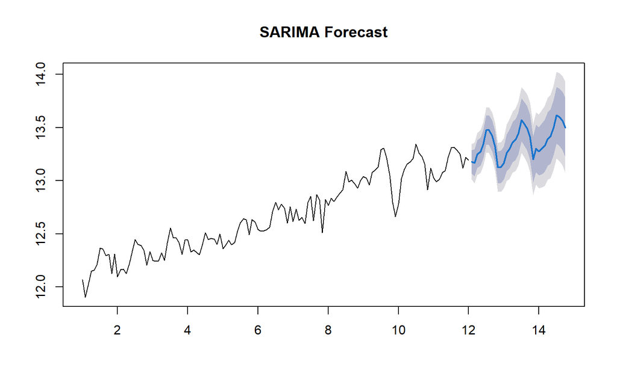

```r
plot(ramalan, main = "SARIMA Forecast")
```

```r
ramalan <- exp(ramalan$mean)
vv <- exp(data_stlh_intervensi)
```

# analisis intervensi

```r
#========IDENTIFIKASI ORDE INTERVENSI
deteksi_outlier<-tsoutliers::tso(ts_training, types =c("AO","LS","TC"), maxit.iloop = 10, tsmethod ="arima")
```

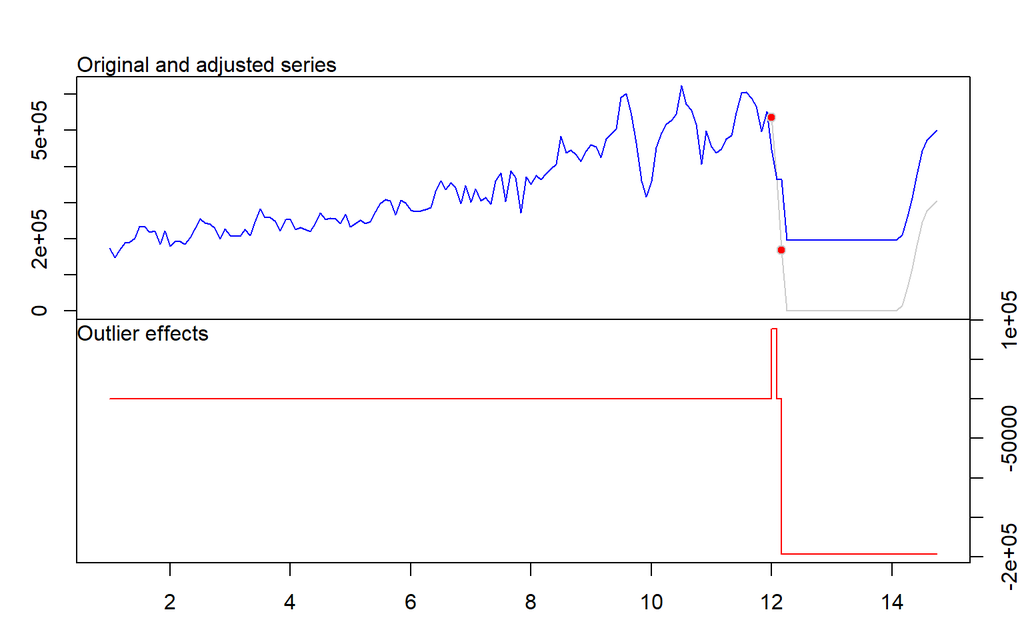

```r
plot(deteksi_outlier)
```

```r
 ## Analisis Intervensi ##
par(mfrow=c(1,1))
forecast_int<-predict(model8,11)
forecast_int<-forecast_int$pred
forecast_int<-ts(forecast_int, frequency = 12)
forecast_int
```

```
##        Jan      Feb      Mar      Apr      May      Jun      Jul      Aug
## 1 13.17971 13.16901 13.25262 13.27483 13.34713 13.47540 13.47726 13.42188
##        Sep      Oct      Nov
## 1 13.32174 13.12580 13.13099
```

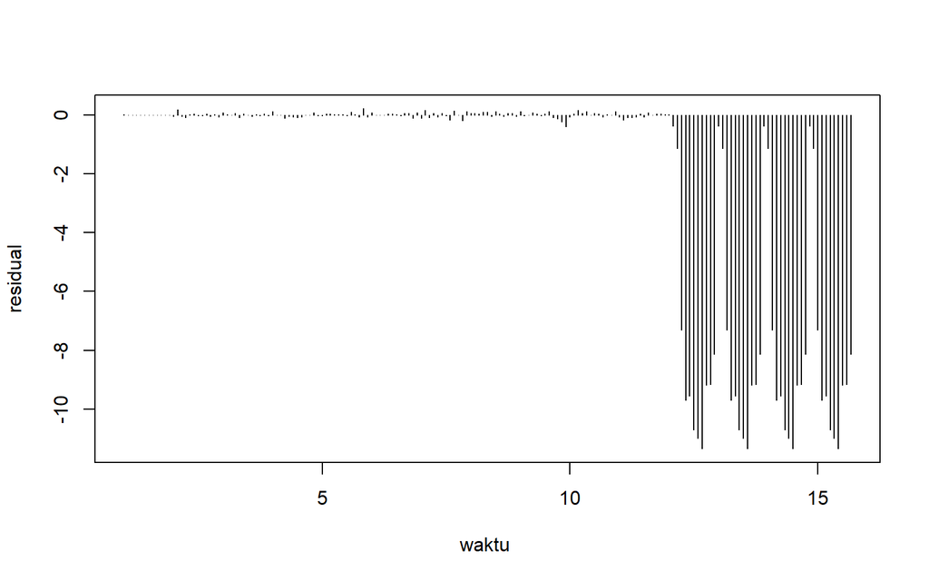

```r
error_idintv<-rep(0,177)
error_idintv[1:133]<-model8$residuals
resi<-(data_stlh_intervensi)-(forecast_int)
error_idintv[134:177]<-resi
error_idintv<-ts(error_idintv,frequency=12)
ts.plot(error_idintv, type="h", xlab="waktu ", ylab="residual", xaxt="n")
abline(h=c(-3*112951.8, 3*112951.8), col="red", lyt=1)
abline(v=2020.2, col="blue", lty=1, lwd=2)
text(2020.1, "T=123",cex =0.8, pos = 3)
```

```r
#Data hasil peramalan
library(readxl)
ts_testings <- ts(ts_testings, frequency = 12)
deta5<-read_excel("C:\\Users\\User\\Documents\\raziq\\semseter 5\\MPDW\\prediksii.xlsx", sheet = 2)
ramalan_intervensi5 <-ts(deta5, frequency = 12)
ramalan_intervensi5<-round(ramalan_intervensi5,0)

d <- as.numeric(ramalan_intervensi5)
t <- as.numeric(ts_testings)

mape(t,d)
```

```
## [1] 0.1866634
```

```r
# Fungsi untuk menghitung MAPE
calculate_mape <- function(actual, forecast) {
  mean(abs((actual - forecast) / actual) * 100, na.rm = TRUE)
}

# Hitung MAPE
mape_result <- calculate_mape(t, d)
mape_result
```

```
## [1] 18.66634
```

```r
cat("MAPE:", sprintf("%.2f%%", mape_result), "\n")
```

```
## MAPE: 18.67%
```

mape yg dihasilkan 18 %

# Plot perbandingan

### Data peramalan intervensi

```r
#Data hasil peramalan intervensi
library(readxl)
testing_data<-data[167:177,2]
ts_testings<-ts(testing_data, frequency = 12)
ts_testings <- ts(ts_testings, frequency = 12)
deta5<-read_excel("C:\\Users\\User\\Documents\\raziq\\semseter 5\\MPDW\\prediksii.xlsx", sheet = 2)
ramalan_intervensi <-ts(deta5, frequency = 12, start = 2022.9)
```

### Data peramalan LSTM

```r
#data peramalan LSTM
datalstm <- read_excel("C:\\Users\\User\\Documents\\raziq\\semseter 5\\MPDW\\prediksiLSTM3.xlsx")
datalstm <- as.numeric(datalstm$prediksi)
datalstmts <- ts(datalstm, frequency = 12, start = 2022.9)
```

### PLot data keseluruhan perbandingan

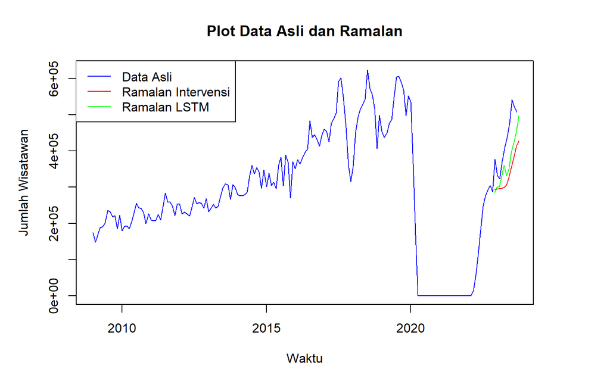

```r
datats <- ts(data[,2], frequency = 12, start = 2009)
# Buat plot data asli
par(mar = c(5, 5, 4, 5))
plot(datats, type = "l", col = "blue", ylim = range(c(datats, ramalan_intervensi, datalstmts)), ylab = "Jumlah Wisatawan", xlab = "Waktu", main = "Plot Data Asli dan Ramalan")

# Tambahkan plot hasil peramalan sesuai dengan waktu
lines(ramalan_intervensi, col = "red", type = "l")
lines(datalstmts, col = "green", type = "l")

# Tambahkan legenda
legend("topleft", legend = c("Data Asli", "Ramalan Intervensi", "Ramalan LSTM"), col = c("blue","red","green"), lty = 1)
```

### Plot perbandingan data test dan peramalan

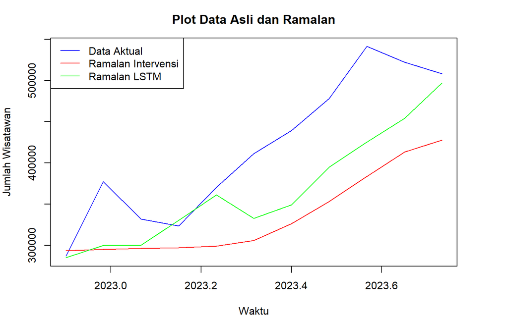

```r
dataaktual <- ts(data[167:177,2],frequency = 12, start = 2022.9)
# Buat plot data asli
par(mar = c(4, 4, 3, 4))
plot(dataaktual, type = "l", col = "blue", ylim = c(min(dataaktual,ramalan_intervensi, datalstmts), max(dataaktual,ramalan_intervensi, datalstmts)), ylab = "Jumlah Wisatawan", xlab = "Waktu", main = "Plot Data Asli dan Ramalan")

# Tambahkan plot hasil peramalan sesuai dengan waktu
lines(ramalan_intervensi, col="red", type = "l")
lines(datalstmts, col = "green", type = "l")

# Tambahkan legenda
legend("topleft", legend = c("Data Aktual", "Ramalan Intervensi", "Ramalan LSTM"), col = c("blue", "red", "green"), lty = 1)
```

# Plot peramalan 20 periode kedepan metode LSTM

```r
#data peramalan LSTM
datalstm20 <- read_excel("C:\\Users\\User\\Documents\\raziq\\semseter 5\\MPDW\\prediksi20(2).xlsx", sheet = 2)

datalstm20ts <- ts(datalstm20, frequency = 12, start = 2009)

datapredik20 <- ts(datalstm20[178:197,], frequency = 12, start = 2023.7)
```

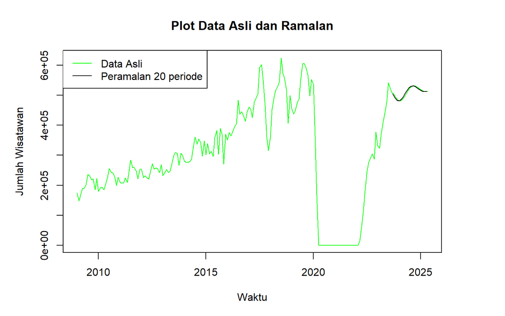

```r
# Buat plot data asli
par(mar = c(5, 5, 4, 5))
plot(datalstm20ts, type = "l", col = "green", ylim = range(c(datalstm20ts)), ylab = "Jumlah Wisatawan", xlab = "Waktu", main = "Plot Data Asli dan Ramalan")


# Tambahkan plot hasil peramalan sesuai dengan waktu
lines(datapredik20, col = "black", type = "l")

# Tambahkan legenda
legend("topleft", legend = c("Data Asli","Peramalan 20 periode"), col = c("green","black"), lty = 1)
```

# Perbandingan MAPE

```r
mape_intervensi <- mape(testing_data,deta5$prediksi) * 100
mape_LSTM <- mape(testing_data,datalstm) * 100

MAPE_Perbandingan <- data.frame( "Model" =c("Intervensi","LSTM"),"MAPE" = c(mape_intervensi,mape_LSTM))

dplyr::arrange(.data=MAPE_Perbandingan, MAPE)
```

```
##        Model     MAPE
## 1       LSTM 11.74061
## 2 Intervensi 18.66635
```